# Lecture 20 Untreated Groups

Nick Huntington-Klein

March 12, 2019

## Recap

- Last time we discussed fixed effects, a prominent real-world causal inference method that sees a lot of use
- Fixed effects is one way of closing many back doors at once by basically comparing individuals to themselves, across time
- This is important given that, in a social science context, the idea that we can really measure and control for *everything* in a back door is often implausible
- However, in many contexts, comparing people to themselves is not possible or desirable

## Today

- Today we’ll be starting to talk about what are called *policy evaluation* methods
- Where we have some *treatment* that has been applied to some people and not others
- (or sometimes, more to some people and less to others)
- And our goal is to figure out how we can compare the treated and the untreated in a way that makes sense
- i.e., apples to apples

## The Basic Problem

- It’s common in the “treatment effects” world to refer to the treatment variable as `D`, which is binary (0 or 1)
- Weird, I guess, but no reason not to stick with it. We want to identify `D -> Y` in this (simplified) diagram:

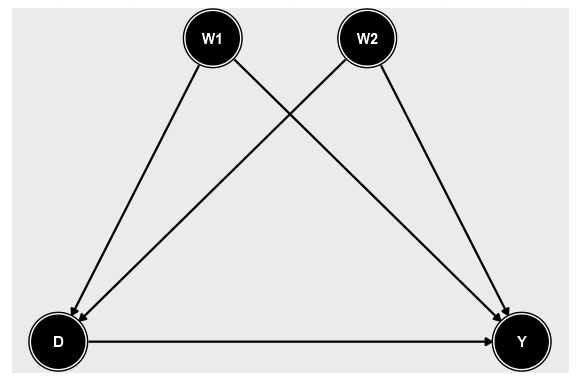

## Matching

- We’re going to start with a procedure called *matching*
- Matching is actually much more common outside of economics than inside
- But it’s something you’ll want to know if you end up in data science
- Plus, it’s a good illustration of the concept here

## Matching

- The basic idea of matching is to remember: picking a sample where people have similar levels of `W` is one way of controlling for `W`
- Well, why don’t we pick that sample intentionally?
- We take our treated observations (`D=1`), look at their `W`s, and pick non-treated observations with similar (or identical) values of `W`

## Remember

- This is just one way of controlling!
- So, like when we were controlling with our explain-and-subtract method, in order for this to work we need to measure and match on *all* variables we need to control for to close back doors
- Why do this when we can just do the other method?
- Some nice statistical properties, other not-so-nice ones, conceptually simple. It’s not overwhelmingly better

## Matching

- There are *many* methods for matching.
- What we’re going to do is first cover the basic concept
- And then we will actually perform *one* variant of matching called Coarsened Exact Matching

## Matching

Every matching estimator follows the same basic concept:

1. Pick a set of variables `W1`, `W2`, etc., to match on
2. Separate out the treated and untreated
3. For each treated observation, check how “close” each untreated observation is on the matching variables
4. Compare the average treated `Y` vs. the average untreated `Y`, *counting untreated obs more heavily the closer they are*

Many many many ways to do 3 and 4. Here’s one…

## For example, Caliper Matching

- In order to do a caliper match on a variable `W`, what you do is:
  1. Pick a caliper size `a`. The smaller it is, the closer the match, but the smaller your eventual sample is
  2. For each treated observation `i`, find all *untreated* observations for which their `W` is within `a` of `W[i]` (e.g. if `a=.1` and the treated observation has `W = 2`, find the untreated observations with `W >= 1.9 & W <= 2.1`)
  3. Drop all untreated observations that don’t have a match (i.e. weight matched observations fully, drop unmatched ones completely)
  4. Compare the average `Y` across treatment

## Caliper Matching

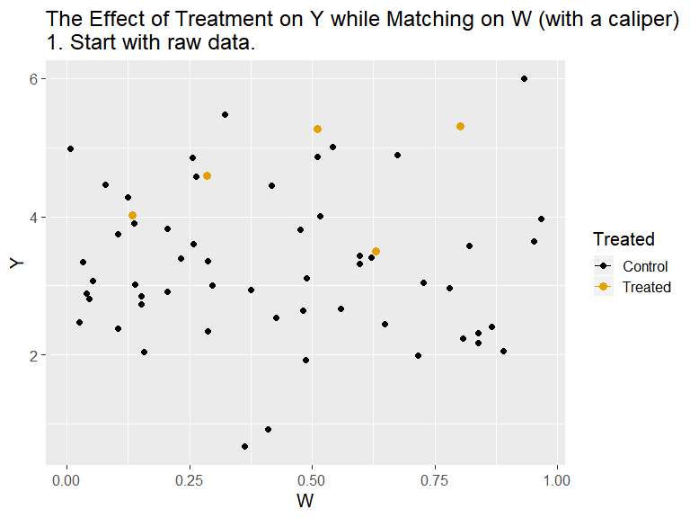

## Coarsened Exact Matching

- A relatively new entrant to the matching world is Coarsened Exact Matching. This is the one we’re going to actually *do*
- I want to be very clear: this isn’t the *best* version of matching or anything like that
- It’s just one that we can actually carry out with our current tools.
- And it is pretty popular anywhere you have big data. Data science people sometimes call it looking for “doppelgangers”

## Coarsened Exact Matching

- The basic idea of Coarsened Exact Matching is that you only count someone as a match if they are the same as the treatment variable *exactly, on every matching variable*
- This is of course impossible with continuous variables, so you split those into bins (“coarsening” them) first
- Make sure to weight the untreated observations so each treated observation is matched to the same number of untreated ones
- Bonus: this is the easiest way, in this class, to control for more than one variable

## Coarsened Exact Matching

- Let’s see if there’s a wage premium to being in a union
- Of course, many back doors: different demographics, or more experienced workers, certain kind of jobs, or be more common in particular regions

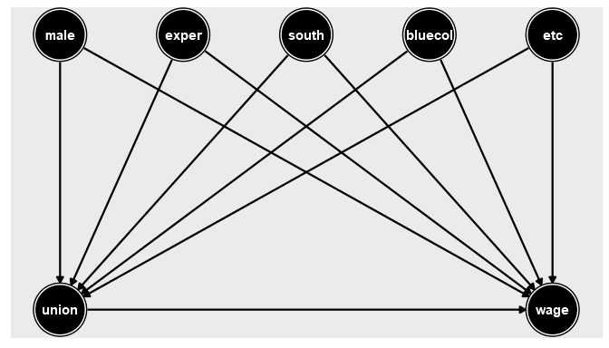

## Coarsened Exact Matching

- So let’s compare union members to non-union members in the Panel Study of Income Dynamics from 1976-1982 that are EXACTLY THE SAME on:
- Gender, years of experience, living in the south, blue-collar job, living in a city (SMSA), being married, being black, and years of education
- Years of experience and years of education are continuous, so we’ll need to coarsen (`cut()`) them first

## Coarsened Exact Matching

```r
library(Ecdat)
data(Wages)

#Coarsen
Wages <- Wages %>% mutate(ed.coarse = cut(ed,breaks=3),
                        exp.coarse = cut(exp,breaks=3))
#Split up the treated and untreated
union <- Wages %>% filter(union=='yes')
nonunion <- Wages %>% filter(union=='no') %>%
  #For every potential complete-match, let's get the average Y
  group_by(ed.coarse,exp.coarse,bluecol,
           ind,south,smsa,married,sex,black) %>%
  summarize(untreated.lwage = mean(lwage))
```

## Coarsened Exact Matching

- `join`, aka merging, is how you can link up two data sets when they match on a list of variables, i.e. “exact matches”!
- There are many flavors of `join` (see `help(join)`). The one we want is `inner_join()` which only keeps successful matches, both treated and untreated

```r
union %>% inner_join(nonunion) %>%
  summarize(union.mean = mean(lwage),nonunion.mean=mean(untreated.lwage))
```

```
##   union.mean nonunion.mean
## 1   6.687606      6.571178
```

```r
#Original union and nonunion counts, and matched union count
c(sum(Wages$union=='yes'),sum(Wages$union=='no'),nrow(union %>% inner_join(nonunion)))
```

```
## [1] 1516 2649 1274
```

## Coarsened Exact Matching

- 6.688 vs. 6.571 - not bad! A 0.116 difference
- Which, since we used log wage, means a 11.6% wage bump for being in a union!
- Compared to - and this is the whole point - a comparable “control” group

## Control Groups

- Remember, that’s the point of matching (and, really, controlling generally), to find the untreated observations that can serve as a control group to compare to our treated group
- We can’t observe what *would* have happened in the counterfactual where they didn’t get treatment, but if we pick the most-comparable untreated group possible, that’s about as close as we can get!

## Control Groups

- And if we assume that the variables we picked are enough to block all the back doors, then picking a comparable (i.e. back-doors-closed) control group is exactly what we did!
- It’s the same idea as our remove-explained-variation approach to controlling, but it’s more explicit about the idea that this is what we’re doing - constructing a “control group”

## Control Groups

- This basic concept turns out to be behind a *lot* of causal inference methods
- Many involve variants on matching, like Propensity Score Matching, which matches on your estimated “propensity” to get treatment, or Inverse Probability Weighting, where we don’t *drop* you for not matching, we just *downweight* you, or Synthetic Control where you also match on outcomes from before treatment, and see how outcomes change after treatment is applied to just some of the groups
- But there are also a lot that don’t use matching at all, and construct control groups in different ways

## Control Groups

- And we might need some other method, right? After all, with the methods for controlling for stuff we have, we have to measure everything, and that’s just not possible!
- Fixed effects helped a little - they control for everything *fixed* about an individual, saving us a lot of trouble. But that doesn’t cover everything!
- We ideally want to have some way of constructing a comparison group that *doesn’t* require us to measure everything

## The Experimental Ideal

- When we run a randomized experiment, we are basically making sure that, on average, the treated and control groups are exactly the same before we apply treatment
- Not just on variables we measure, but also on variables we don’t!
- Because we assigned it randomly, any given variable will be, on average, the same in the treated and control group
- This is basically what we’re trying to mimic, and force to be the case, with matching. But we can only do it for what we observe

## Natural Experiments

- As we move forward, other approaches to picking control groups will have to do with trying to get even closer to this experimental ideal
- Picking treatment and control groups in such a way that, in that context, assignment to treatment basically *is* random
- When we manage to do this, find “random” experiments in observational data, we call this a *natural experiment*

## Natural Experiments

- You can think of natural experiments as trying to do matching *without doing matching*
- A natural experiment is when you find a context, and potentially a subgroup, where the treatment and control groups are already matched, not just on what you can measure, but also on what you can’t
- We will start with the first of these methods, called difference-in-difference, next time.

## Practice

- Does having kids in the house affect how much time you spend eating? Install and load the `atus` package, from the American Time Use Survey. Load the `atusresp` and `atusact` data sets.
- Filter `atusact` to `tiercode==110101` (eating and drinking). Then `inner_join` it with `atusresp`. Call the result `eating` and `ungroup()` it
- Limit the data to dur, hh_child, labor_status, student_status, work_hrs_week, partner_hh, weekly_earn, tuyear
- `eating <- na.omit(eating)` to nuke missing data
- Get mean difference of `dur` by `hh_child`, matching on everything else, using `cut(,breaks=5)` for everything that’s not a factor.

## Practice Answers

```r
library(atus)
data(atusresp)
data(atusact)
eating <- atusact %>% filter(tiercode==110101) %>% inner_join(atusresp) %>% ungroup() %>%
  select(dur, hh_child, labor_status, student_status, work_hrs_week, partner_hh, weekly_earn, tuyear) %>%
  na.omit() %>%
  mutate(hrs.c = cut(work_hrs_week,breaks=5),earn.c = cut(weekly_earn,breaks=5),year.c = cut(tuyear,breaks=5))

kids <- filter(eating,hh_child=='yes')
nokids <- eating %>% filter(hh_child=='no') %>%
  group_by(hrs.c,earn.c,year.c,labor_status,student_status,partner_hh) %>%
  summarize(nokids.dur = mean(dur))
kids %>% inner_join(nokids) %>% summarize(kids.dur=mean(dur),nokids.dur=mean(nokids.dur))
```

```
## # A tibble: 1 x 2
##   kids.dur nokids.dur
##      <dbl>      <dbl>
## 1     68.0       71.9
```